# Guide to spotoroo

The hot spot data, or the Moderate Resolution Imaging Spectroradiometer (MODIS) hot spot data, is usually taken from satellite for burning fire detection. An example of this kind of data is the [*Himawari-8 Wild Fire product*](https://www.eorc.jaxa.jp/ptree/documents/README_H08_L2WLF.txt) provided by the Japan Aerospace Exploration Agency (JAXA).

This vignette shows you how to cluster satellite hot spots, detect ignition points and reconstruct fire movement using the `spotoroo` package.

Load the `spotoroo` package using the `library()` function.

```r
library(spotoroo)
```

# Data requirements

In order to use the spatiotemporal clustering algorithm provided by the `spotoroo` package, the satellite hot spot data needs to be stored in a `list` which have at least three fields: the **observed time**, the **longitude** and the **latitude**.

The **observed time** needs to be an object inherited from one of these classes:

- `Date`
- `POSIXlt`
- `POSIXct`
- `numeric`

Besides, the **longitude** and the **latitude** needs to be in `numeric`.

Using the built-in dataset `hotspots` as an example, it is a `data.frame` with a `lon` (**longitude**) `numeric` column, a `lat` (**latitude**) `numeric` column and a `obsTime` (**observed time**) `POSIXct` column.

```r
str(hotspots)
```

```
#> 'data.frame':    1070 obs. of  3 variables:
#>  $ lon    : num  147 146 143 149 142 ...
#>  $ lat    : num  -37.5 -37.9 -37.8 -37.4 -37.1 ...
#>  $ obsTime: POSIXct, format: "2020-02-01 05:20:00" "2020-01-02 06:30:00" ...
```

This dataset contains 1070 selected hot spots in Victoria (Australia) during the 2019-2020 Australian bushfire season. More details about this dataset can be found by using the function `help(hotspots)`

# Overview of the hot spot data

A common way to get a better understanding of the hot spot data is to visualize it. This package provides a function `plot_vic_map()` (package `sf` needs to be installed) to draw a map of Victoria. It returns a `ggplot` object, so new layers could be added onto it. Here we use `geom_point()` to draw red dots for hot spots.

From the map, we observe that there are approximately $4$ clusters, but we don’t know if they can be further broken down into more clusters. Our goal is to cluster these hot spots into fires in a temporal and spatial manner.

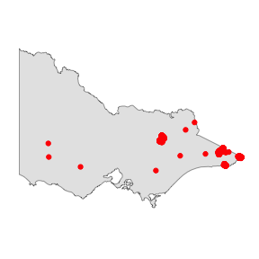

```r
library(ggplot2)
if (requireNamespace("sf", quietly = TRUE)) {
    plot_vic_map() +
    geom_point(data = hotspots, aes(lon, lat), col = "red")
}
```

If you would like to visualize the hot spots in other areas, you might be able to find the spatial data from the `rnaturalearth` package and make a similar map using the `geom_sf()` and `ggthemes::theme_map()` function. An example is given below.

```r
# NOT RUN
ggplot() +
  geom_sf(data = your_map, aes(geometry = geometry)) +
  geom_point(data = your_hotspots, aes(lon, lat), col = "red") +
  ggthemes::theme_map()
```

# Spatiotemporal clustering of hot spot

**`hotspot_cluster()` is the main function of this package. In most of the cases, you only need to use this function to perform the spatiotemporal clustering algorithm.**

## Arguments

This function has $11$ arguments, which can be divided into four categories:

### 1. specifications of the dataset

| Arguments | Description |
| --- | --- |
| `hotspots` | the object that contains the dataset |
| `lon` | the name of the longitude column |
| `lat` | the name of the latitude column |
| `obsTime` | the name of the observed time column |

The first four arguments are pretty straight forward, you only need to provide the dataset object and its corresponding column names.

### 2. specifications of the parameters of the clustering algorithm

| Arguments | Description |
| --- | --- |
| `activeTime` | the time tolerance |
| `adjDist` | the distance tolerance |
| `minPts` | the minimum number of hot spots |
| `minTime` | the minimum length of time |

These four arguments control the clustering process.

In practice, we usually don’t have knowledge about the parameters `activeTime` and `adjDist`, but in general, the number of clusters will decrease when you increase these two parameters.

Comparing the clustering results under different settings is an available method to determine these two parameters. We will show how to do this in the section Additional topic: Choice of parameters.

In terms of `minPts` and `minTime`, they depend on your personal preference of noise reduction. And, the number of clusters will often decrease when you increase these two parameters.

A sensible choice of these two parameters is `minPts` $\in [3,10]$ and `minTime` $\in [1~hour, 12~hours]$

### 3. specification of the calculation of the ignition points

| Arguments | Description |
| --- | --- |
| `ignitionCenter` | method of the calculation of the ignition points |

For a cluster, if `ignitionCenter` is “mean”, the centroid of the earliest hot spots will be used as the ignition point, if `ignitionCenter` is “median”, the median longitude and the median latitude of these hot spots will be used as the ignition point.

In usual, there is no significant difference between these two methods, so we recommend to set `ignitionCenter = "mean"`.

### 4. specifications of the transformation of the observed time

| Arguments | Description |
| --- | --- |
| `timeUnit` | the unit of time |
| `timeStep` | the number of time unit one time index contains |

Due to the design of the algorithm, the observed time needs to be transformed to discrete time index. Available time units are “d” (days), “h” (hours), “m” (minutes), “s” (seconds) and “n” (numeric). `timeUnit = "n"` will only be accepted when the observed time is already a `numeric` vector.

For example, if `timeUnit` is “h” and `timeStep` is $2$, then the difference between time index $1$ and time index $2$ is $2$ hours.

## Usage

With specifications of all the arguments, the `hotspot_cluster()` can be used as below. Generally, you need to use an object to catch the return.

```r
result <- hotspot_cluster(hotspots = hotspots,
                          lon = "lon",
                          lat = "lat",
                          obsTime = "obsTime",
                          activeTime = 24,
                          adjDist = 3000,
                          minPts = 4,
                          minTime = 3,
                          ignitionCenter = "mean",
                          timeUnit = "h",
                          timeStep = 1)
```

```
#>
#> ──────────────────────────────── SPOTOROO 0.1.4 ────────────────────────────────
#>
#> ── Calling Core Function : `hotspot_cluster()` ──
#>
#> ── "1" time index = 1 hour
#> ✔ Transform observed time → time indexes
#> ℹ 970 time indexes found
#>
#> ── activeTime = 24 time indexes | adjDist = 3000 meters
#> ✔ Cluster
#> ℹ 16 clusters found (including noise)
#>
#> ── minPts = 4 hot spots | minTime = 3 time indexes
#> ✔ Handle noise
#> ℹ 6 clusters left
#> ℹ noise proportion : 0.935 %
#>
#> ── ignitionCenter = "mean"
#> ✔ Compute ignition points for clusters
#> ℹ average hot spots : 176.7
#> ℹ average duration : 131.9 hours
#>
#> ── Time taken = 0 mins 1 sec for 1070 hot spots
#> ℹ 0.001 secs per hot spot
#>
#> ────────────────────────────────────────────────────────────────────────────────
```

Messages produced by this function tell you some important information of the clustering results such as the number of discrete time indexes, the number of clusters and the proportion of noise. If you would like to silent this function, you could wrap this function with the `suppressMessages()` function like the example given below.

```r
# NOT RUN
suppressMessages(hotspot_cluster())
```

## Returns

The `hotspot_cluster()` function returns a `spotoroo` object, which is actually a `list` contains a `data.frame` called `hotpsots`, a `data.frame` called `ignition` and a `list` called `setting`.

If you evaluate the `result` or print it, you will get a concise description of the clustering results. Here, according to the output, we know there are $6$ clusters in the clustering results.

```r
result
```

```
#> ℹ spotoroo object: 6 clusters | 1070 hot spots (including noise points)
```

You can access these two `data.frame`s in the usual way.

```r
head(result$hotspots, 2)
```

```
#>      lon       lat             obsTime timeID membership noise distToIgnition
#> 1 147.46 -37.46000 2020-02-01 05:20:00    809         -1  TRUE              0
#> 2 146.48 -37.93999 2020-01-02 06:30:00     90         -1  TRUE              0
#>   distToIgnitionUnit timeFromIgnition timeFromIgnitionUnit
#> 1                  m          0 hours                    h
#> 2                  m          0 hours                    h
```

```r
head(result$ignition, 2)
```

```
#>   membership    lon    lat             obsTime timeID obsInCluster
#> 1          1 149.30 -37.77 2019-12-29 13:10:00      1          146
#> 2          2 146.72 -36.84 2020-01-08 01:40:00    229          165
#>   clusterTimeLen clusterTimeLenUnit
#> 1 116.1667 hours                  h
#> 2 148.3333 hours                  h
```

The `hotspots` dataset contains information of each hot spot. Particularly, the `membership` column is the membership label column. $-1$ represents noise.

The `ignition` dataset contains information of each cluster. Similarly, the `membership` column is the membership label column. And the `lon` and `lat` are the coordinate information of the ignition points.

### Extract a subset of clusters

If you would like to extract a subset of clusters from the results or merge the `hotspots` and `ignition` dataset, you could use the function `extract_fire()`.

You could choose to extract all clusters along with noise points by setting `cluster = "all"` and `noise = TRUE`. This will merge the `hotspots` and `ignition` dataset.

```r
# Merge the `hotspots` and `ignition` dataset
merged_result <- extract_fire(result, cluster = "all", noise = TRUE)
```

You could also only extract a subset of clusters without any noise by providing a vector of membership labels to the argument `cluster` and set `noise = FALSE`. This will merge the `hotspots` and `ignitoin` dataset but filtering out the noise points and selecting needed clusters.

```r
# Merge the `hotspots` and `ignition` dataset
# Select cluster 2 and 3 and filter out noise
cluster_2_and_3 <- extract_fire(result, cluster = c(2, 3), noise = FALSE)
```

## Additional topic: Choice of parameters

In principal, the parameters `activeTime` and `adjDist` are determined using the professional knowledge of fire behaviour, but in practice, we generally don’t know much about them.

In the rest of the section, we will show one of the methods to choose proper values for these two parameters.

We first set `minPts = 4` and `minTime = 3`. You could set different values for `minPts` and `minTime` if you like.

We then could do a grid search for `activeTime` and `adjDist` in a sensible range. Here, we set `adjDist` $\in$ `[500,1000,1500,2000,2500,3000,3500,4000]` and `activeTime` $\in$ `[6,12,18,24,30,36,42,48]`. For each pair of `activeTime` and `adjDist`, we record the proportion of noise as the metric for comparison.

The following code does the calculation. It may takes around 10 minutes to run. You could have a try if you like.

```r
# NOT RUN
# NOTICE: MAY TAKE AROUND 10 MINS TO RUN THIS CODE BLOCK
noise_prop <- c()

for (adjDist in seq(500, 4000, 500)) {
  for (activeTime in seq(6, 48, 6)) {
    result <- suppressMessages(hotspot_cluster(hotspots = hotspots,
                                               lon = "lon",
                                               lat = "lat",
                                               obsTime = "obsTime",
                                               activeTime = activeTime,
                                               adjDist = adjDist,
                                               minPts = 4,
                                               minTime = 3,
                                               ignitionCenter = "mean",
                                               timeUnit = "h",
                                               timeStep = 1))

    noise_prop <- c(noise_prop, mean(result$hotspots$noise))
  }
}

tab <- expand.grid(activeTime = seq(6, 48, 6),
                   adjDist = seq(500, 4000, 500))

tab$noise_prop <- noise_prop
```

With the proportion of noise, we could make two line plots to reveal the relationships between proportion of noise, `adjDist` and `activeTime`.

It works like the [scree plot](https://en.wikipedia.org/wiki/Scree_plot) used in principal component analysis. We want to keep clusters separate without introducing too much noise.

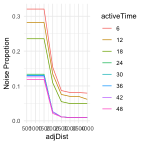

```r
ggplot(tab) +
  geom_line(aes(adjDist, noise_prop, color = as.factor(activeTime))) +
  ylab("Noise Propotion") +
  labs(col = "activeTime") +
  theme_minimal() +
  scale_x_continuous(breaks = seq(500, 4000, 500))
```

In the second plot, most of the significant drops of proportion of noise are observed when `activeTime` less than 24 hours. Therefore, `activeTime = 24` is a reasonable choice.

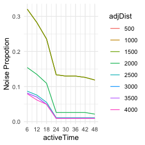

```r
ggplot(tab) +
  geom_line(aes(activeTime, noise_prop, color = as.factor(adjDist))) +
  ylab("Noise Propotion") +
  labs(col = "adjDist") +
  theme_minimal() +
  scale_x_continuous(breaks = seq(6, 48, 6))
```

# Exploring the spatiotemporal clustering results

The package provides some useful functions to explore the clustering results.

## Summary

You could make a brief summary of the clustering results.

```r
summary_spotoroo(result)
```

```
#>
#> ──────────────────────────────── SPOTOROO 0.1.4 ────────────────────────────────
#>
#> ── Calling Core Function : `summary_spotoroo()` ──
#>
#> CLUSTERS: ALL
#> OBSERVATIONS: 1070
#> FROM: 2019-12-29 13:10:00
#> TO:   2020-02-07 22:50:00
#>
#> ── Clusters
#> ℹ Number of clusters: 6
#>
#> Observations in cluster
#>         Min.     1st Qu.        Mean     3rd Qu.        Max.
#>        111.0       131.0       176.7       233.2       256.0
#> Duration of cluster (hours)
#>         Min.     1st Qu.        Mean     3rd Qu.        Max.
#>        111.2       118.2       131.9       146.1       148.3
#>
#> ── Hot spots (excluding noise)
#> ℹ Number of hot spots: 1060
#>
#> Distance to ignition points (m)
#>         Min.     1st Qu.        Mean     3rd Qu.        Max.
#>          0.0      2840.3      5058.2      6981.6     13452.7
#> Time from ignition (hours)
#>         Min.     1st Qu.        Mean     3rd Qu.        Max.
#>          0.0        25.2        62.5        98.2       148.3
#>
#> ── Noise
#> ℹ Number of noise points: 10 (0.93 %)
#>
#> ────────────────────────────────────────────────────────────────────────────────
```

Or make a brief summary of a subset of clusters by providing a vector of membership labels to the `cluster` argument.

```r
summary_spotoroo(result, cluster = c(1, 3, 4))
```

### Called by `summary()`

For convenience, the `summary_spotoroo()` can be called by the `summary()` function.

```r
summary(result)
summary(result, cluster = c(1, 3, 4))
```

## Plot

You could produce a plot of the clustering results. There are three types of plots, which are “def” (default), “mov” (fire movement) and “timeline” (timeline).

### Default

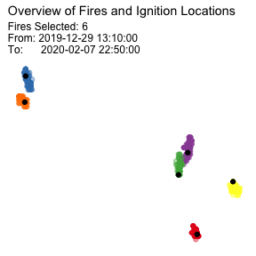

```r
plot_spotoroo(result, type = "def")
```

### Timeline

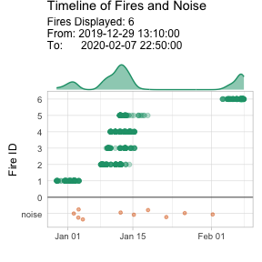

```r
plot_spotoroo(result, type = "timeline")
```

### Fire movement

The fire movement is calculated from the `get_fire_mov()` function.

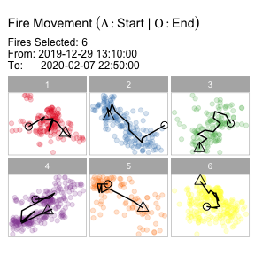

```r
plot_spotoroo(result, type = "mov", step = 6)
```

### Add a background

If you have a background `ggplot` object, you can let the function plots onto it.

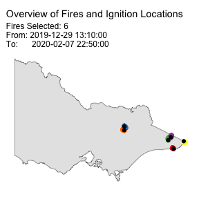

```r
if (requireNamespace("sf", quietly = TRUE)) {
  plot_spotoroo(result, bg = plot_vic_map())
}
```

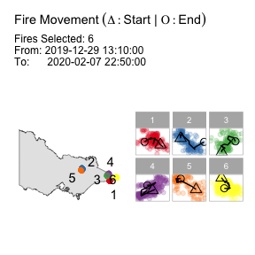

```r
if (requireNamespace("sf", quietly = TRUE)) {
  plot_spotoroo(result, type = "mov", bg = plot_vic_map(), step = 6)
}
```

More details about the usage of this function can be found by using the `help(plot_spotoroo)` function.

### Called by `plot()`

For convenience, the `plot_spotoroo()` can be called by the `plot()` function.

```r
plot(result)
plot(result, type = "timeline")
plot(result, type = "mov")
plot(result, bg = plot_vic_map())
plot(result, type = "mov", bg = plot_vic_map())
```